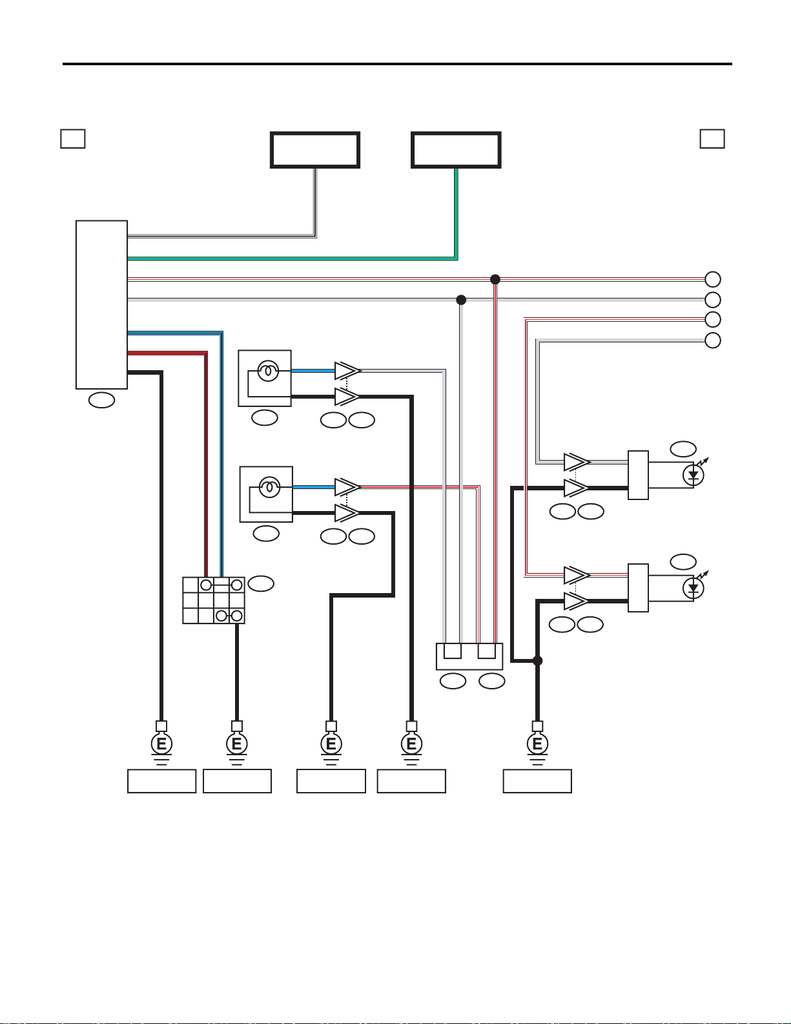

WI-406

Turn Signal Light and Hazard Light System

WIRING SYSTEM

56.Turn Signal Light and Hazard Light System

A: WIRING DIAGRAM

WI-44596

a a

20

3

20

3

B71

A

B

B32

RH

OFF

LH

D

C

F13

i76 D83

2

3

F1 F6

2

3

F4 F21

D15

i101 D84

D5

F10

F109 B360

C:B:

W/B

G/L

R/B

L/B

13

15

B

B

B

12

B

GR

W/R

W/R

GR

B17

B16

C13

C14

B

B

GR

W/R

GR

W/R

B7

L/B5

1B

1B

2L

2L

B

B

W/R

GR

R/B6

3

2

1

4

W/R

GR

W/B

G/L

GR

B5

1

B

GR

B

5

1

B

OUTER MIRROR

ASSY LH

OUTER MIRROR

ASSY RH

FRONT TURN

SIGNAL LIGHT RH

THROUGH

JOINT

CONNECTOR

FRONT TURN

SIGNAL LIGHT LH

TURN SIGNAL &

HAZARD MODULE

FB-34

F/B FUSE NO. 11

(IG)

MB-28

M/B FUSE NO. 14

(B)

REF. TO GND

[a]

REF. TO GND

[b]

REF. TO GND

[b]

TURN SIGNAL

SWITCH

REF. TO GND

[j]

REF. TO GND

[a]

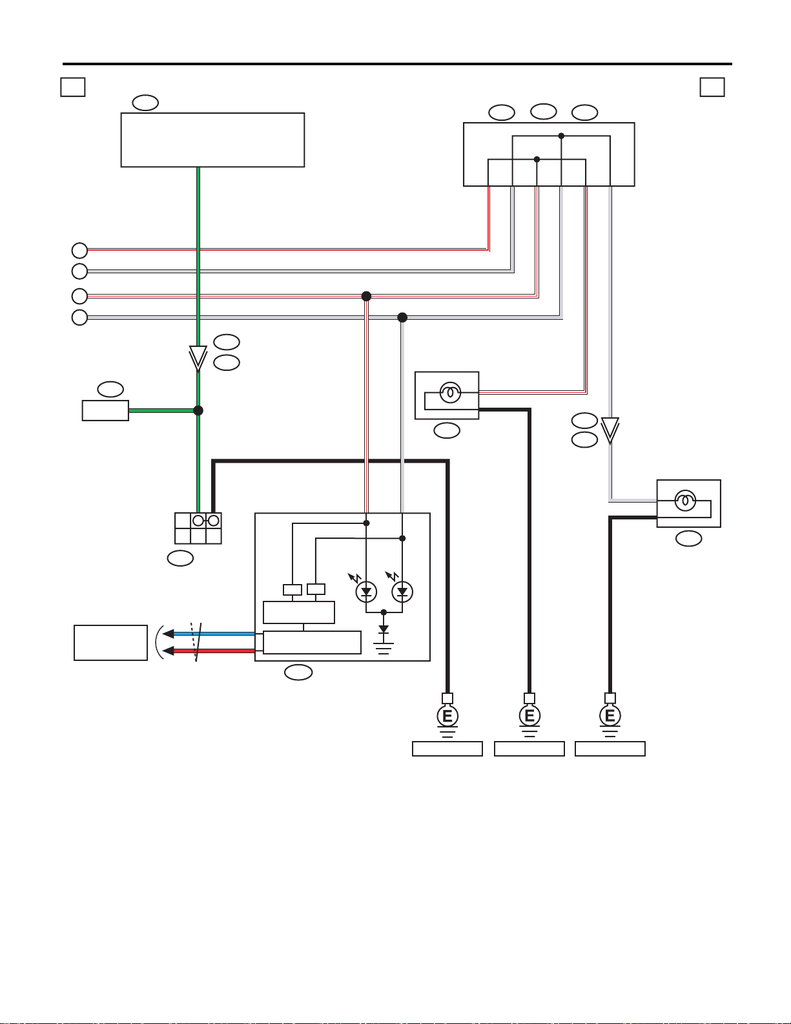

WI-407

Turn Signal Light and Hazard Light System

WIRING SYSTEM

2

R26

R168

B:

R28

R82

R81

W/R

B20

B3

B

B

GR 3

W/R3

B

2

B2

GR

GR

REAR

COMBINATION

LIGHT LH

REAR

COMBINATION

LIGHT RH

WI-44597

b b

10

i230

B552

i171D:

i5

A: C:

B52

F/B

i22

ON

OFF

B32

B

A

i10

I/F

I/F

RHLH

B

G

3

2 G8

B

GG

4

6

GR

W/R

GR

GR C18

W/R A18

GR A12

GR

C

W/R

D

GR

W/R

W/R C9

G

W/R

D18

R33

L32

REF. TO CAN

COMMUNICATION

SYSTEM [b]

REF. TO GND [e]

CAN TRANSCEIVER &

RECEIVER

MICRO

COMPUTER

BODY INTEGRATED UNIT

COMBINATION METER

TURN SIGNAL & HAZARD MODULE

HAZARD

SWITCH

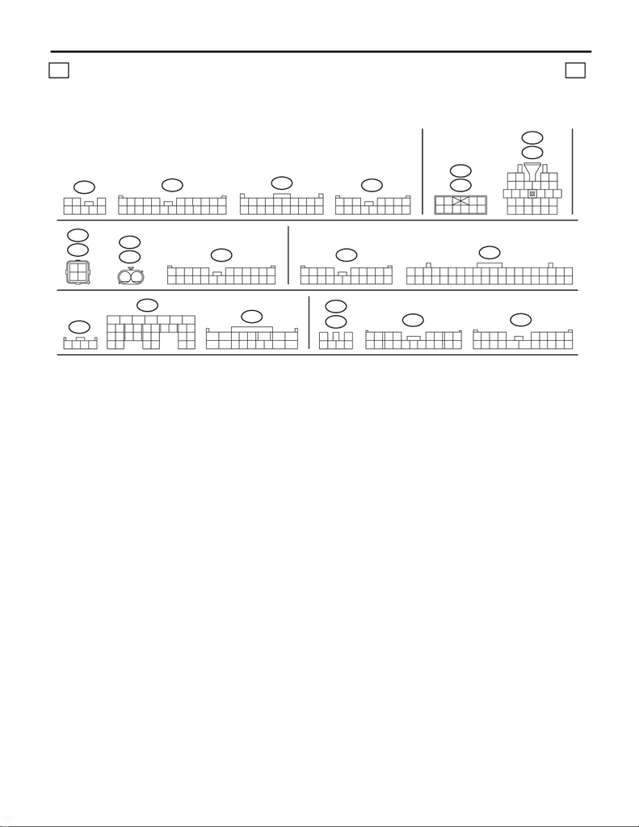

WI-408

Turn Signal Light and Hazard Light System

WIRING SYSTEM

F13

12

(GR)

F10

(GR)

3412 89

10 11

12 13 14 15 16 17 18 19 20 21 22 23 24

567

B52

C:

3412 89

10 11

12 13 14 15 16 17 18 19 20 21 22 23 24

567

F109

B:

WI-44598

c c

i10

11 12

9

10

2

15 1613 14 19

18

20

21 22 23 24 26

25

27 28 29 30 31 32 33 34 35 36 37 38 39 40

17

i171D:

19

18

20 21

22

23

26

24

25

27

28 29

30 31

98

15

1413121110

17

16

1234567

B32

12 3

45678

B71

123456789

10

11 12 13 14 15 16 17 18 19 20

C:

(GR)

B360

123 4567

89

10 11 12 13 14 15 16

D15

D5

10

978

6

5

3

4

12

A:

89

19 20

1234 567

10 11 12 13 14 15 16 17 18

i5

i22

341

2 5

6

34

21

R28

R26

R168B:

1234

56789

10 11 12 13 14 15 16 17 18 19 20

(GR)

F6

(GR)

F21

12

34

i230

(GR)

10

13

345 6

14 15 16 17

1211

12 78

9

(B)

R82

1

9

234 5678

10 11 12 14 15 16 17 18 1913

D84

D83

19

18

20 21 22

1514131211

1

3

24

5

7

6

98

10

17

25

24

26 27 2823

16

LIST OF CONNECTORS